# DATA 622: PREDICTIVE ANALYTICS HW 2

## Correlation

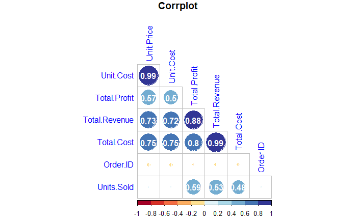

```r
corr_matrix <- cor(df_1k_num)
corrplot(corr_matrix,
         type = "lower",
         order = "hclust",
         tl.col = "blue",
         addCoef.col = "white",
         diag = FALSE,
         title = "Corrplot",
         mar = c(0, 0, 1, 0),
         col = brewer.pal(10, "RdYlBu"))
```

Looking at the correlation plot we see the following:

- Weak correlation between Unit.Price, Unit.Cost and Units.Sold
- Mild correlation between Total.Profit, Total.Revenue, Total.Cost and Units.Sold
- Mild correlation between Unit.Price, Unit.Cost and Total.Profit
- High correlation between Unit.Price and Unit.Cost
- High correlation between Total.Profit and Total Revenue
- High correlation between Total,Cost and Total.Revenue

I suspect multicollinearity but will use and additional method to confirm.

## VIF

```r
set.seed(321)

sample_1k_train <- df_1k_num$Total.Revenue %>%
  createDataPartition(p = 0.8, list = FALSE)
df_train_1k  <- df_1k_num[sample_1k_train, ]
df_test_1k <- df_1k_num[-sample_1k_train, ]


model<- lm(Total.Revenue~., data=df_train_1k )

vif_values<-car::vif(model)

print(vif_values)
```

```
    Order.ID   Units.Sold   Unit.Price    Unit.Cost   Total.Cost Total.Profit
    1.002970     3.041373   167.637725   167.273600    11.445468    14.149909
```

The values interpret as: * Order.ID has low multicollinearity * Units.Sold low multicollinearity * Unit.Price and Unit.Cost has high levels of multicollinearity * Total.Cost and Total.Profit has moderate levels of multicollinearity.

# Transformation

Only transformation needed are: * date values to Month, Day and Year * levels for categorical values. * scaling for pre-processing for modelling * Attribute selection of relevant data will also be best

```r
df_1k[['Order.Date']] <- as.Date(df_1k[['Order.Date']], "%m/%d/%Y")
df_1k[['Ship.Date']] <- as.Date(df_1k[['Ship.Date']], "%m/%d/%Y")

df_1k[['Sales.Channel']] <- as.factor(df_1k[['Sales.Channel']])

df_1k[['Order.Priority']] <- as.factor(df_1k[['Order.Priority']])

df_1k[['Item.Type']] <- as.factor(df_1k[['Item.Type']])

df_1k[['Region']] <- as.factor(df_1k[['Region']])

df_1k[['Country']] <- as.factor(df_1k[['Country']])

df_1k[['Order.ID']] <- as.character(df_1k[['Order.ID']])

df_1k_norm<-predict(preProcess(df_1k, method=c("center", "scale")),df_1k)
```

```r
df_1k_norm %>%
  keep(is.numeric) %>%
  describe(fast=TRUE) %>%
  select(-c(vars,n))
```

```
Error in select(., -c(vars, n)) : unused argument (-c(vars, n))
```

```r
df_1k_norm <- df_1k_norm %>%
  select(-c(Country,Order.ID,))
```

# Models

## Regression trees

### Model 1

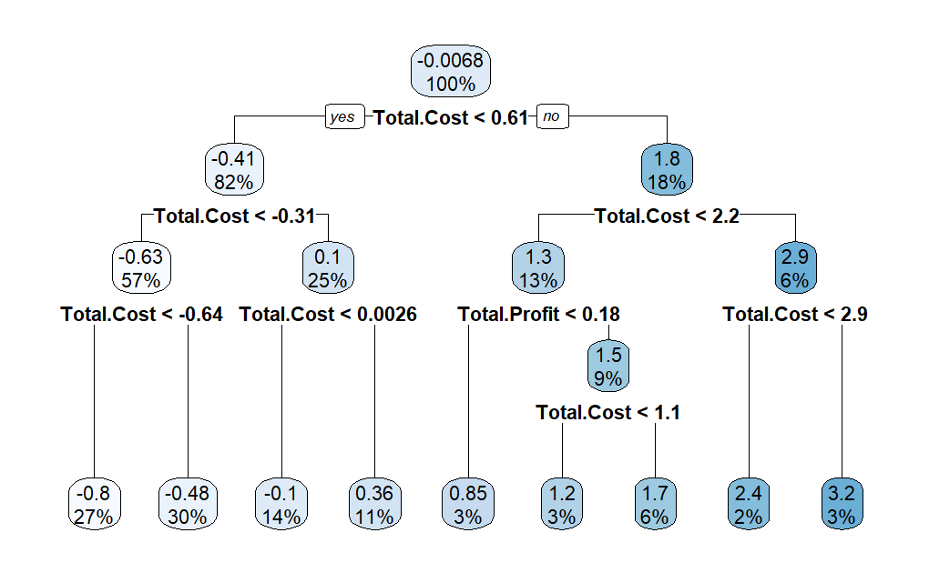

```r
set.seed(1234)

df1k_norm1 <- df_1k_norm

#split
training_1k_samples <- df1k_norm1$Total.Revenue %>%
  createDataPartition(p = 0.8, list = FALSE)

train_1k1  <- df1k_norm1[training_1k_samples, ]
test_1k1 <- df1k_norm1[-training_1k_samples, ]

#train using rpart, cp- complexity, smaller # = more complexity,
#method- anova is for regression
tree_1k1 <- rpart(Total.Revenue ~., data = train_1k1, cp = 0.004,  method = 'anova')

#visualize
rpart.plot(tree_1k1)
```

```r
print(tree_1k1)
```

```
n= 800

node), split, n, deviance, yval
      * denotes terminal node

 1) root 800 789.9383000 -0.006752507
   2) Total.Cost< 0.6147312 654 108.3324000 -0.410574000
     4) Total.Cost< -0.3106351 456  16.8432000 -0.634194800
       8) Total.Cost< -0.6429517 216   1.1617710 -0.802689100 *
       9) Total.Cost>=-0.6429517 240   4.0300370 -0.482550000 *
     5) Total.Cost>=-0.3106351 198  16.1706800  0.104431600
      10) Total.Cost< 0.002629725 109   1.8064560 -0.101871600 *
      11) Total.Cost>=0.002629725 89   4.0434160  0.357095100 *
   3) Total.Cost>=0.6147312 146  97.2280900  1.802146000
     6) Total.Cost< 2.244415 102  19.0550000  1.348138000
      12) Total.Profit< 0.1788319 27   1.5098580  0.846133500 *
      13) Total.Profit>=0.1788319 75   8.2913770  1.528860000
        26) Total.Cost< 1.124162 25   1.4624880  1.217733000 *
        27) Total.Cost>=1.124162 50   3.1988910  1.684424000 *
     7) Total.Cost>=2.244415 44   8.4097410  2.854619000
      14) Total.Cost< 2.891512 18   0.9282189  2.399053000 *
      15) Total.Cost>=2.891512 26   1.1594990  3.170012000 *
```

**Predictions**

```r
predictions <- predict(tree_1k1, newdata = test_1k1) %>%
  bind_cols(test_1k1 )

predictions$...1 <- as.numeric(predictions$...1)
```

**Performance**

```r
decision_tree_model <- data.frame(Model = "Decision Tree 1",

MAE = ModelMetrics::mae(predictions$Total.Revenue, predictions$...1),
#rmse Root Mean Squared Error
RMSE = ModelMetrics::rmse(predictions$Total.Revenue, predictions$...1),
#r squared
R2 = caret::R2(predictions$Total.Revenue, predictions$...1)
)

decision_tree_model
```

| Model | MAE | RMSE | R2 |
| --- | --- | --- | --- |
| Decision Tree 1 | 0.1215621 | 0.1660607 | 0.9737615 |

### Model 2

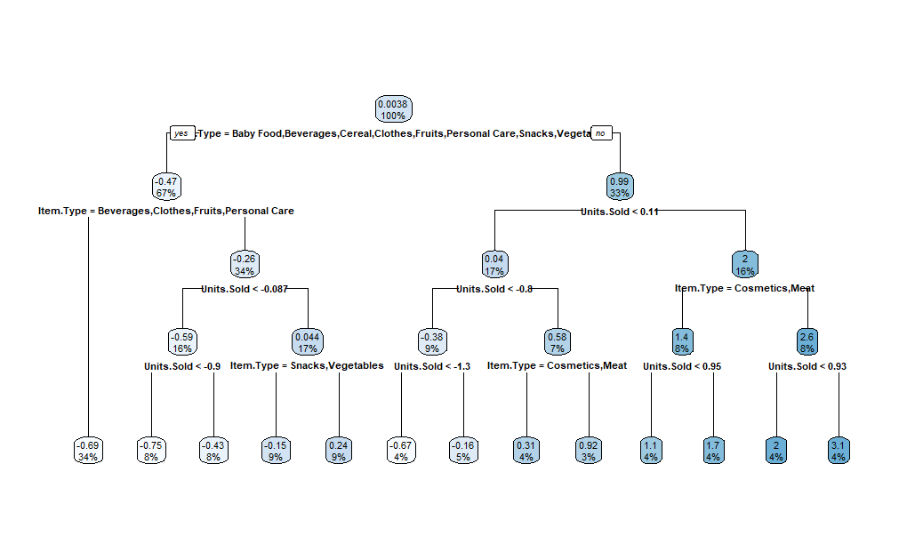

```r
set.seed(4321)

df_1k_norm2 <- df_1k_norm %>%
  select(-c("Unit.Price","Unit.Cost","Total.Cost", "Total.Profit"))

#split
training_1k_samples2 <- df_1k_norm2$Total.Revenue %>%
  createDataPartition(p = 0.8, list = FALSE)

train_1k2  <- df_1k_norm2[training_1k_samples2, ]
test_1k2 <- df_1k_norm2[-training_1k_samples2, ]

#train using rpart, cp- complexity, smaller # = more complexity,
#method- anova is for regression
tree_1k2 <- rpart(Total.Revenue ~., data = train_1k2, cp = 0.004, method = 'anova')

#visualize
rpart.plot(tree_1k2)
```

```r
print(tree_1k2)
```

```
n= 800

node), split, n, deviance, yval
      * denotes terminal node

 1) root 800 822.8269000  0.003789579
   2) Item.Type=Baby Food,Beverages,Cereal,Clothes,Fruits,Personal Care,Snacks,Vegetables 539  75.4121000 -0.474707900
     4) Item.Type=Beverages,Clothes,Fruits,Personal Care 270   8.8690330 -0.685383800 *
     5) Item.Type=Baby Food,Cereal,Snacks,Vegetables 269  42.5309600 -0.263248700
      10) Units.Sold< -0.08719589 131   4.9589340 -0.587279500
        20) Units.Sold< -0.9037052 64   0.4596006 -0.751204600 *
        21) Units.Sold>=-0.9037052 67   1.1367960 -0.430694400 *
      11) Units.Sold>=-0.08719589 138  10.7607700  0.044345760
        22) Item.Type=Snacks,Vegetables 69   1.2076570 -0.148450800 *
        23) Item.Type=Baby Food,Cereal 69   4.4235870  0.237142300 *
   3) Item.Type=Cosmetics,Household,Meat,Office Supplies 261 369.1487000  0.991951000
     6) Units.Sold< 0.1121923 133  47.2663700  0.039783430
      12) Units.Sold< -0.7953083 75   6.9743660 -0.381010600
        24) Units.Sold< -1.301275 32   0.6975396 -0.671731000 *
        25) Units.Sold>=-1.301275 43   1.5595200 -0.164660400 *
      13) Units.Sold>=-0.7953083 58   9.8394350  0.583913600
        26) Item.Type=Cosmetics,Meat 32   1.5942220  0.310831200 *
        27) Item.Type=Household,Office Supplies 26   2.9217760  0.920015000 *
     7) Units.Sold>=0.1121923 128  76.0103700  1.981313000
      14) Item.Type=Cosmetics,Meat 63   7.7936750  1.394445000
        28) Units.Sold< 0.9454178 28   0.7889117  1.056832000 *
        29) Units.Sold>=0.9454178 35   1.2600410  1.664536000 *
      15) Item.Type=Household,Office Supplies 65  25.4882900  2.550122000
        30) Units.Sold< 0.9302526 32   3.0820170  1.987527000 *
        31) Units.Sold>=0.9302526 33   2.4563190  3.095669000 *
```

**Predictions**

```r
predictions2 <- predict(tree_1k2, newdata = test_1k2) %>%
  bind_cols(test_1k2)

predictions2$...1 <- as.numeric(predictions2$...1)
```

**Performance**

```r
decision_tree_model2 <- data.frame(Model = "Decision Tree 2",
#mean absolute error
MAE = ModelMetrics::mae(predictions2$Total.Revenue, predictions2$...1),
#rmse Root Mean Squared Error
RMSE = ModelMetrics::rmse(predictions2$Total.Revenue, predictions2$...1),
#r squared
R2 = caret::R2(predictions2$Total.Revenue, predictions2$...1)
)

decision_tree_model2
```

| Model | MAE | RMSE | R2 |
| --- | --- | --- | --- |
| Decision Tree 2 | 0.1645788 | 0.2060202 | 0.9540491 |

## Random Forest Regression Tree

```r
set.seed(222)
rf <- randomForest::randomForest(formula = Total.Revenue ~ .,
                   data = train_1k1, importance=TRUE)
```

```r
rf
```

```
Call:
 randomForest(formula = Total.Revenue ~ ., data = train_1k1, importance = TRUE)
               Type of random forest: regression
                     Number of trees: 500
No. of variables tried at each split: 3

          Mean of squared residuals: 0.001567821
                    % Var explained: 99.84
```

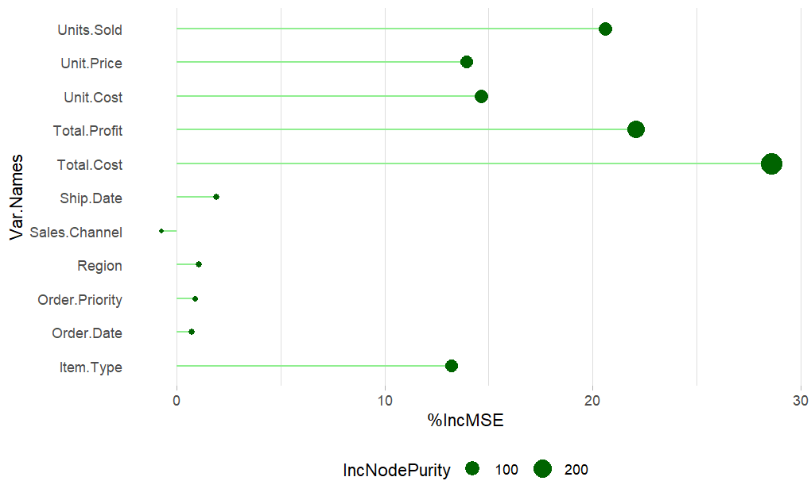

```r
ImpData <- as.data.frame(importance(rf))
ImpData$Var.Names <- row.names(ImpData)

ggplot(ImpData, aes(x=Var.Names, y=`%IncMSE`)) +
  geom_segment( aes(x=Var.Names, xend=Var.Names, y=0, yend=`%IncMSE`), color="lightgreen") +
  geom_point(aes(size = IncNodePurity),  color="darkgreen", alpha=1) +
  theme_light() +
  coord_flip() +
  theme(
    legend.position="bottom",
    panel.grid.major.y = element_blank(),
    panel.border = element_blank(),
    axis.ticks.y = element_blank()
  )
```

```r
NA
NA
```

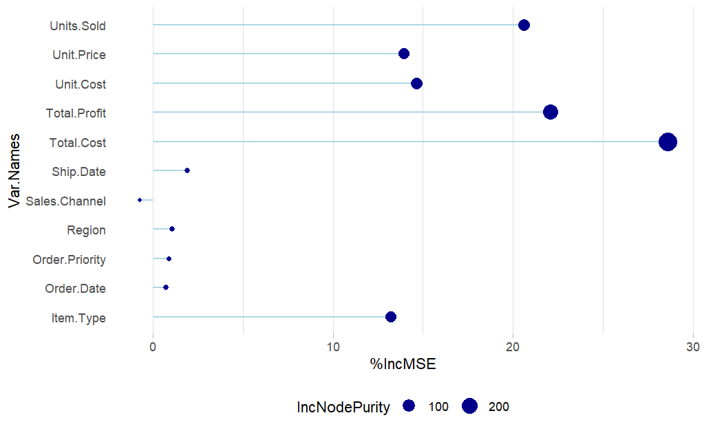

```r
ggplot(ImpData, aes(x=Var.Names, y=`%IncMSE`)) +
  geom_segment( aes(x=Var.Names, xend=Var.Names, y=0, yend=`%IncMSE`), color="lightblue") +
  geom_point(aes(size = IncNodePurity),  color="darkblue", alpha=1) +
  theme_light() +
  coord_flip() +
  theme(
    legend.position="bottom",
    panel.grid.major.y = element_blank(),
    panel.border = element_blank(),
    axis.ticks.y = element_blank()
  )
```

**Predictions**

```r
predictions3 <- predict(rf, newdata = test_1k1) %>%
  bind_cols(test_1k1)

predictions3$...1 <- as.numeric(predictions3$...1)
```

**Performance**

```r
random_forest_model <- data.frame(Model = "Random Forest",
#mean absolute error
MAE = ModelMetrics::mae(predictions3$Total.Revenue, predictions3$...1),
#rmse Root Mean Squared Error
RMSE = ModelMetrics::rmse(predictions3$Total.Revenue, predictions3$...1),
#r squared
R2 = R2(predictions3$Total.Revenue, predictions3$...1)
)

random_forest_model
```

| Model | MAE | RMSE | R2 |
| --- | --- | --- | --- |
| Random Forest | 0.0209061 | 0.04107028 | 0.9988368 |